# DATABASE FINAL PROJECT

Sowmya, Aditya

12/17/2021

```r
library(odbc)
library(DBI)
library(skimr)
library(ggplot2)
```

Setting connection to our database in Azure using an R library called DBI.

```r
con <- dbConnect(odbc(), Driver = "SQL Server", Server = "gene.database.windows.net",
    Database = "GENE_DB", UID = "sowmyap", PWD = "HA78BGb&s4%m",
    Port = 1433)
```

## Query1

Find the total gene counts for each spot.

```sql
/*spotcountsdf is the R object that is outputted from this query */
SELECT SUM(counts) AS spot_counts, spotid FROM gene_counts
GROUP BY spotid;
```

The skim function in R from the skimr library gives a comprehensive summary of

spotcountsdf as seen below.

```r
skim(spotcountsdf)
```

Data summary

| Name | spotcountsdf |
| --- | --- |
| Number of rows | 4992 |
| Number of columns | 2 |
| _______________________ |  |
| Column type frequency: |  |
| character | 1 |
| numeric | 1 |
| ________________________ |  |
| Group variables | None |

**Variable type: character**

| skim_variable | n_missing | complete_rate | min | max | empty | n_unique | whitespace |
| --- | --- | --- | --- | --- | --- | --- | --- |
| spotid | 0 | 1 | 18 | 18 | 0 | 4992 | 0 |

**Variable type: numeric**

| skim_variable | n_missing | complete_rate | mean | sd | p0 | p25 | p50 | p75 | p100 | hist |
| --- | --- | --- | --- | --- | --- | --- | --- | --- | --- | --- |
| spot_counts | 0 | 1 | 0.04 | 0.2 | 0 | 0 | 0 | 0 | 2 | ▇▁▁▁▁ |

## Query 2

```sql
SELECT TOP 1 * FROM coldata;
```

```r
query2
```

```
##   cell_count ground_truth     sample_id         barcode_id in_tissue array_row
## 1         NA           NA sample_151673 AAACAACGAATAGTTC-1     FALSE         0
##   array_col pxl_col_in_fullres pxl_row_in_fullres
## 1        16               2435               3913
```

Query 2: We want to find the proportion of zeros to nonzero cell count in our db

```sql
SELECT zeros/nonzeros FROM Z,ZN;
```

```r
proportion
```

```
##
## 1 0
```

## Query 3

Find all image pixels associated with layer 1.

```sql
SELECT pxl_row_in_fullres, pxl_col_in_fullres FROM coldata
WHERE ground_truth = 'Layer1' ;
```

```r
layer1
```

```
##     pxl_row_in_fullres pxl_col_in_fullres
## 1                 5769               2807
## 2                10101               3677
## 3                 6527               2693
## 4                 4115               3035
## 5                 5147               3162
## 6                 3979               2795
## 7                 5633               2567
## 8                 6113               2930
## 9                 3634               2912
## 10                4661               3758
## 11                6181               3050
## 12                4666               3039
## 13                6733               2814
## 14                5565               2447
```

[output cut: 259 more lines]

Now, using the ggplot library in R, we can plot these pixel values to figure out the shape of layer 1 in our tissue image as seen below.

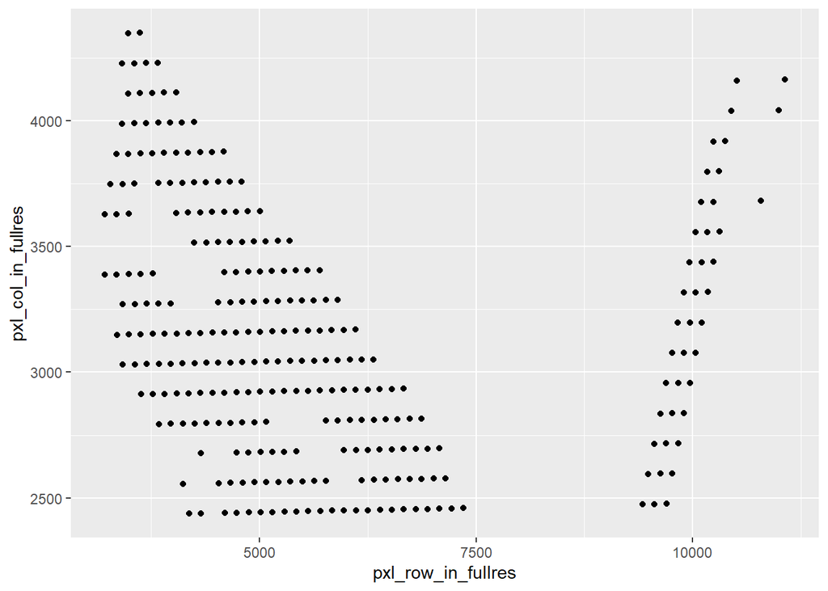

```r
ggplot(data=layer1, aes(
            x=pxl_row_in_fullres, y=pxl_col_in_fullres)
       ) + geom_point()
```

## Query 4

```sql
SELECT MAX(array_row) FROM coldata;
```

```r
max_array_row
```

```
##
## 1 77
```

```sql
SELECT MAX(array_col) FROM coldata;
```

```r
print(max_array_col)
```

```
##
## 1 127
```

```sql
SELECT  DISTINCT geneid FROM coldata, gene_counts WHERE
gene_counts.spotid = coldata.barcode_id AND
counts >0 AND
array_row > 77/2 AND
array_col > 127/ 2;
```

```r
# list of genes
query4
```

```
##            geneid
## 1 ENSG00000223764
## 2 ENSG00000225880
## 3 ENSG00000230368
## 4 ENSG00000237491
## 5 ENSG00000238009
## 6 ENSG00000243485
```

Select the spot with the highest proportion of mitochondrial genes.

## Query 5

```sql
SELECT TOP 1 mt/nonmt AS proportion FROM M, N
WHERE M.spotid = N.spotid;
/*ORDER BY proportion DESC  ; */
```

```r
query5
```

```
## [1] proportion
## <0 rows> (or 0-length row.names)
```

We get zero rows with mitchondrial genes, perhaps none of them were captured for this layer of the brain.

We have genomic database, but we also want to explore data on people who image this tissues and help create these datasets. While information on this is not readily available due to security reasons, we imagined what such relations would look like, made fake data, and have explored them here.

For query 8, we want to explore the number of users outside of Baltimore that work with such datasets. The answer we get is 27.

Many genes are not detected in the tissue. Let’s retrieve the ones that are expressed.

## Query 6

```sql
SELECT DISTINCT gene_name FROM rowdata, gene_counts
    WHERE rowdata.gene_id = gene_counts.geneid AND gene_counts.counts >= 1
```

```r
query6
```

```
##     gene_name
## 1  AL627309.1
## 2  AL645608.1
## 3  AL669831.5
## 4      FAM41C
## 5      FAM87B
## 6   LINC00115
## 7 MIR1302-2HG
## 8      SAMD11
```

## Query 7

Print the range of cell counts found across all spots and the frequencies of these numbers.

```sql
SELECT  cell_count, count(*) AS freq FROM coldata
GROUP BY cell_count;
```

```r
query7
```

```
##    cell_count freq
## 1           0   84
## 2          23    1
## 3           9   92
## 4          15    3
## 5           3  623
## 6          26    2
## 7          12   18
## 8           6  421
## 9          21    2
## 10         27    1
## 11         NA 1353
## 12          7  287
## 13          1  211
## 14         18    1
## 15         10   50
## 16          4  617
## 17         19    2
## 18         25    2
## 19         13   10
## 20          5  541
## 21         22    1
## 22         16    8
## 23          2  483
## 24         17    2
## 25         11   25
## 26         20    3
## 27         14    9
## 28          8  140
```

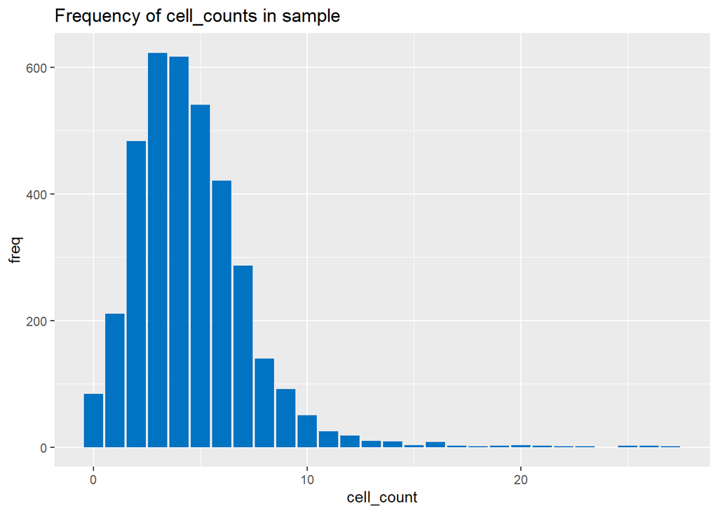

```r
ggplot(query7, aes(x = cell_count, y = freq)) +
  geom_bar(fill = "#0073C2FF", stat = "identity") +
    ggtitle('Frequency of cell_counts in sample')
```

## Query 8

```sql
SELECT count(*) FROM users AS U ,institutions AS I, zipcode as Z
where Z.City != 'Baltimore' AND I.zipcode = Z.Zipcode AND
u.institution_id = i.institutionid ;
```

```r
query8
```

```
##
## 1 27
```

## Query 9

Query 9 gives the gene name that is expressed the most in the tissue.

```sql
SELECT TOP 1 SUM(counts) , gene_name FROM gene_counts , rowdata, coldata
WHERE gene_counts.geneid = rowdata.gene_id AND gene_counts.spotid = coldata.barcode_id
GROUP BY gene_name ORDER BY SUM(counts) DESC ;
```

```r
query9
```

```
##        gene_name
## 1 110 AL669831.5
```

## Query 10

For query 10, let’s see who first joined the institution, and the name of the institution that has the most number of people working on spatial transcriptomics dataset.

```sql
SELECT TOP 1 fname, lname, username, institutions.name FROM Institutions, U, Users
WHERE num_users = (SELECT MAX(num_users) FROM U) AND
Institutions.institutionid = Users.institution_id AND U.institution_id = users.institution_id
ORDER BY date_joined;
```

```r
query10
```

```
##   fname lname   username                              name
## 1   Amy  York TcKYPsZxAP University of California Berkeley
```

## Query 11

Query 11 outputs the email id of all people working with a specific person stored in J.

```sql
SELECT users.Email_Id FROM users, J
WHERE
users.institution_id = J.institution_id;
```

```r
query11
```

```
##                           Email_Id
## 1  Benjamin_Wallace2975@nanoff.biz
## 2    Adeline_Whatson3759@jiman.org
## 3          Percy_Lee631@nickia.com
## 4      Rebecca_Kelly4321@yahoo.com
## 5     Harriet_Bailey3707@sheye.org
## 6        Vicky_Dyson553@gembat.biz
## 7       Ron_Faulkner7308@qater.org
## 8       Denny_James4954@muall.tech
## 9         Brad_Page 3490@vetan.org
## 10    Audrey_Brooks7485@twipet.com
## 11       Clint_Hall3478@muall.tech
## 12  Winnie_Randall9782@irrepsy.com
## 13    Holly_Goodman8150@gompie.com
## 14    Sarah_Rowlands2674@brety.org
## 15    Luke_Vallory9152@cispeto.com
```

## Query 12

Print the first and last names of people who previously worked at Johns Hopkins but currently work for another institution.

```sql
SELECT U.fname, U.lname FROM Users AS U, Users AS V, Institutions AS I
WHERE
 U.UserID = V.UserID AND U.Institution_Id = I.institutionid AND
U.date_joined < V.date_joined AND
I.name = 'Johns Hopkins';
```

```r
query12
```

```
## [1] fname lname
## <0 rows> (or 0-length row.names)
```

This query was interesting to figure out since it required a special function DATEDIFF() to calculate the differences between two dates (normal arithmetic subtraction doesn’t work on it)

```sql
SELECT sample_id, br_region, scanned_by FROM TissueSample WHERE
    DATEDIFF(dy,tr_date,  scan_date) >= 2 ;
```

```r
`query 13`
```

```
##    sample_id br_region  scanned_by
## 1     136917     DLPFC 233-42-0542
## 2     231370     DLPFC 735-75-6884
## 3     737948  Cerebrum 160-73-4627
## 4     927804  Cerebrum 022-86-2672
## 5     532524  Cerebrum 573-24-0568
## 6     826894  Cerebrum 120-03-8321
## 7     354639     DLPFC 004-68-6005
## 8     211661     DLPFC 206-01-5734
## 9     501323      Pons 562-44-5781
## 10    964619      Pons 712-31-3623
## 11    498015   Medulla 374-32-2024
## 12    192967   Medulla 312-66-3741
## 13    280561   Medulla 465-34-2011
## 14    937042   Medulla 070-83-7450
## 15    611741  Amygdala 302-00-0673
## 16    520092  Amygdala 550-75-0021
## 17    367511  Amygdala 453-57-0332
## 18    748729  Amygdala 874-46-0120
## 19    854492  Amygdala 483-62-5157
```

Let’s see whether we can find a certain array row in our coldata aka spot data. If it exists, return the number of cell counts associated with that spot. Let’s select array row = 156

```sql
IF EXISTS (SELECT * FROM coldata WHERE array_row= 156)
SELECT cell_count FROM coldata WHERE array_row = 156;
```

```r
query14
```

```
## data frame with 0 columns and 0 rows
```

Looks like we don’t have any spots associated with array row 156.

```sql
SELECT TOP 1 AVG(CAST(MONTH(scan_date)AS int)) AS avg_month,
AVG(CAST(YEAR(scan_date)AS int)) AS avg_year,
AVG(CAST(DAY(scan_date)AS int)) AS avg_day,
Platform_num

FROM tissuesample
WHERE Platform_num != 'NA'
GROUP BY Platform_num
ORDER BY avg_day, avg_month, avg_year DESC;
```

```r
query15
```

```
##   avg_month avg_year avg_day Platform_num
## 1         8     2021       1   V791249780
```